# Session 4 — Repeated Measures and Trajectories

Long format · time × arm · nested random effects · random slopes · AR(1) · missing visits · Lab 4

Community Medicine Workshop

## Where we are

- Session 3: a random intercept for **village**
- Today: the **same person is measured four times**
- By the end you can:
  - look at **trajectories** by group
  - fit **time × arm** with a **nested** random effect
  - decide on a **random slope**
  - fit a **GEE** with AR(1)
  - explain why mixed models cope with **missing visits** (MAR)

# Topic 1 — Looking at trajectories

## Long format

```r
bp |> filter(person %in% c("V01-P01", "V01-P02")) |> select(person, arm, months, sbp)
```

```
# A tibble: 7 × 4
  person  arm       months   sbp
  <fct>   <fct>      <dbl> <dbl>
1 V01-P01 Programme      0   135
2 V01-P01 Programme      3   149
3 V01-P01 Programme      6   134
4 V01-P01 Programme     12   131
5 V01-P02 Programme      0   121
6 V01-P02 Programme      3   136
7 V01-P02 Programme      6   137
```

```r
bp |> count(person) |> count(n, name = "people")
```

```
# A tibble: 4 × 2
      n people
  <int>  <int>
1     1      7
2     2     78
3     3    241
4     4    474
```

**One row per visit** (long format) is what the models need. Only **59%** of people have all four visits.

## Mean SBP by arm and visit

```r
bp |> group_by(arm, months) |> summarise(mean_sbp = mean(sbp), .groups = "drop") |>
  ggplot(aes(months, mean_sbp, colour = arm)) + geom_line(linewidth = 1.2) + geom_point(size = 3) +
  scale_colour_manual(values = c(col_blue, col_red)) + scale_x_continuous(breaks = c(0, 3, 6, 12)) + labs(x = "Months", y = "Mean SBP (mmHg)", colour = NULL)
```

Similar at baseline (randomised). The **programme arm declines** and the **control arm** stays about flat.

## Mean SBP by arm and visit

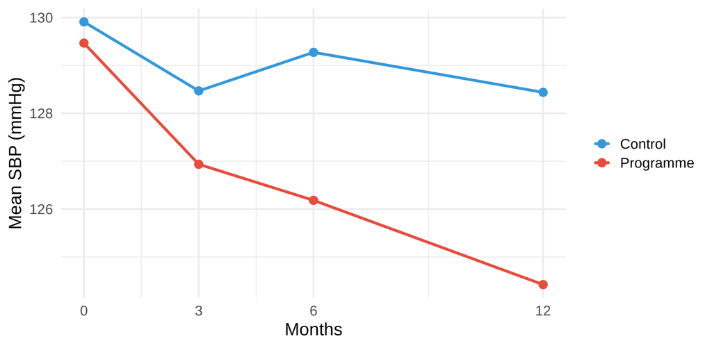

# Topic 2 — The model

## Time × arm with nested random effects

```r
m_t <- lmer(sbp ~ months * arm + age + sex + bmi + (1 | village / person), data = bp)
summary(m_t)$coefficients["months:armProgramme", ] |> round(3)
```

```
  Estimate Std. Error         df    t value   Pr(>|t|)
    -0.385      0.074   2006.760     -5.197      0.000
```

The **interaction** is the **difference in slopes**: the programme arm declines **about 0.4 mmHg per month faster**. `(1 | village / person)` gives a random intercept for each village **and** for each person within it.

## The effect at 12 months

```r
fe <- fixef(m_t)
fe[["armProgramme"]] + 12 * fe[["months:armProgramme"]]
```

```
[1] -4.352272
```

- **arm** alone is the difference **at month 0** (near 0 after randomisation)
- At 12 months: arm + 12 × interaction ≈ **−4.4 mmHg**
- To get a CI for this contrast, use `emmeans` or a linear-combination function
- If the trend is not a straight line, use **months as a factor** or a spline

## Is the interaction within-person or between-village?

The **interaction** compares **changes within people**, so the naive SE is not too small, it is **too large** (0.12 instead of 0.07). Clustering inflates SEs of **between-cluster** effects and can **reduce** them for **within-cluster** effects. That is why the model must follow the design.

# Topic 3 — Slopes, AR(1) and missing data

## A random slope for time

```r
m_s <- lmer(sbp ~ months * arm + age + sex + bmi + (1 | village) + (months | person), data = bp, control = lmerControl(optimizer = "bobyqa"))
anova(m_t, m_s)
```

```
Data: bp
Models:
m_t: sbp ~ months * arm + age + sex + bmi + (1 | village/person)
m_s: sbp ~ months * arm + age + sex + bmi + (1 | village) + (months | person)
    npar   AIC   BIC logLik -2*log(L)  Chisq Df Pr(>Chisq)
m_t   10 21456 21516 -10718     21436
m_s   12 21460 21531 -10718     21436 0.6957  2     0.7062
```

- Allows each person to have their **own trend**
- The likelihood-ratio test has **p ≈ 0.7**: no evidence that trends differ: keep the **simpler** model
- Random slopes need **many** visits per person; with 4 visits the model can fail to converge

## GEE with AR(1)

```r
d <- bp |> arrange(person, months)
g_ar <- geeglm(sbp ~ months * arm + age + sex + bmi, id = person, waves = months, data = d, family = gaussian, corstr = "ar1")
round(summary(g_ar)$coefficients["months:armProgramme", ], 3)
```

```
                    Estimate Std.err   Wald Pr(>|W|)
months:armProgramme   -0.341   0.083 16.715        0
```

- **Population-averaged** slope difference: about **−0.34**, close to the mixed model (**−0.39**)
- **AR(1)**: correlation falls as visits are further apart
- This GEE has `id = person` and so **ignores the village** level

## Missing visits

About **13% of visits are missing**, and dropout is more likely for **older** people and after a **high** SBP. That is **missing at random** (MAR): the reason depends on **observed** values.

```r
complete <- bp |> group_by(person) |> filter(n() == 4) |> ungroup()
c(complete_cases = n_distinct(complete$person), all_people = n_distinct(bp$person))
```

```
complete_cases     all_people
           474            800
```

- The **mixed model** uses **all available visits** and is valid under **MAR** if the model includes the predictors of missingness
- A **complete-case** analysis drops **41% of people** and can be **biased**
- If missingness depends on the **unobserved** value itself (MNAR), neither is safe: run a **sensitivity analysis** (later module)

## 🔧 Switch to R — Lab 4

**File:** `clustered-workshop/labs/lab4_long.R`

- visits per person and a mean-by-arm plot
- `months * arm` with `(1 | village / person)`
- random slope, AR(1) GEE and complete cases

**Time:** 45 minutes · answer the Q questions in the comments

## Self-check quiz (1/5)

What does the months:armProgramme coefficient in the model estimate?

- The difference in mean SBP between arms at month zero
- The difference between arms in the change in SBP per month
- The change in SBP per month in the control arm only
- The fraction of visits that are missing in the programme arm

## Self-check quiz (2/5)

What does (1 | village / person) specify?

- Random slopes for time, estimated separately for each village and each person
- A single random intercept shared by all visits of the people in a village
- A fixed effect for each village and a fixed effect for each person
- A random intercept for village and one for person within village

## Self-check quiz (3/5)

In this model the interaction naive SE (0.12) was larger than the mixed one (0.07). What is the reason?

- It compares change within people, where the clustering can shrink the variance
- A mixed model gives a smaller SE than a naive model for the coefficients it estimates
- Clustering increases the variance of each estimate, and this one is no different
- The naive model had fewer observations available than the mixed model did

## Self-check quiz (4/5)

Under missing at random, why can the mixed model be used with incomplete follow-up?

- It fills the missing visits in with the last value observed for that person
- It drops everyone with a missing visit before the model is fitted to the data
- It uses all observed visits, and dropout depends on values in the model
- It assumes the missing visits would have had the same SBP as the observed ones

## Self-check quiz (5/5)

A random slope for months is tried and the likelihood-ratio p-value is 0.7. What do you conclude?

- The random slope shows that the people in the trial share one identical trend
- There is no evidence that trends differ, so the simpler model is kept
- The model needs to be rerun with months entered as a categorical variable
- The random intercept for village should now be removed from the model

## Score and take-home

**Your score:**

- **Long format**, one row per visit
- **months × arm** = difference in slopes; `(1 | village / person)`
- Within-person comparisons: SE can be **smaller** than a naive one
- **Random slope** only if the data support it
- **MAR**: mixed models use all visits; avoid complete cases

**Next:** Session 5: choosing, checking and reporting